# Manipulación de datos vectoriales

Alexander Quevedo

10 de febrero de 2018

Este manual toma como referencia la publicación realizada por [Robin Lovelace y colaboradores](https://geocompr.robinlovelace.net/), de donde se replicarón algunos ejercicios con fines académicos.

## Primeros pasos en R

Debemos inciar cargando los paquetes necesarios para esto emplearemos el comanto `library()`.

```r
library(sf)
library(sp)
library(spData)
library(spDataLarge)
library(tidyverse)
```

```r
library(mapview)
library(units)
```

A continuación vamos a explorar el conjunto de datos *world*, incluido en la libreria **spData**. Los objetos de característica simples en R se almacenan en un marco de datos, con datos geográficos que ocupan una columna especial, una ‘columna de lista’. Esta columna generalmente se llama `geom` o `geometry`.

```r
names(world)
```

```
##  [1] "iso_a2"    "name_long" "continent" "region_un" "subregion"
##  [6] "type"      "area_km2"  "pop"       "lifeExp"   "gdpPercap"
## [11] "geom"
```

La columna *geom* contiene todas las coordenadas. Ahora vamos a realizar un plot del conjunto de datos *world*

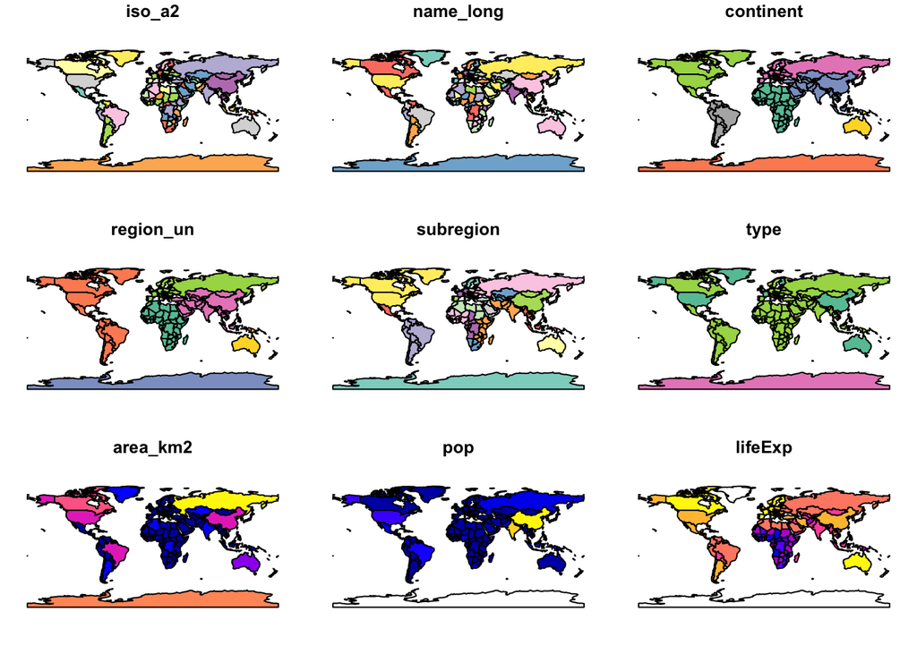

```r
plot(world)
```

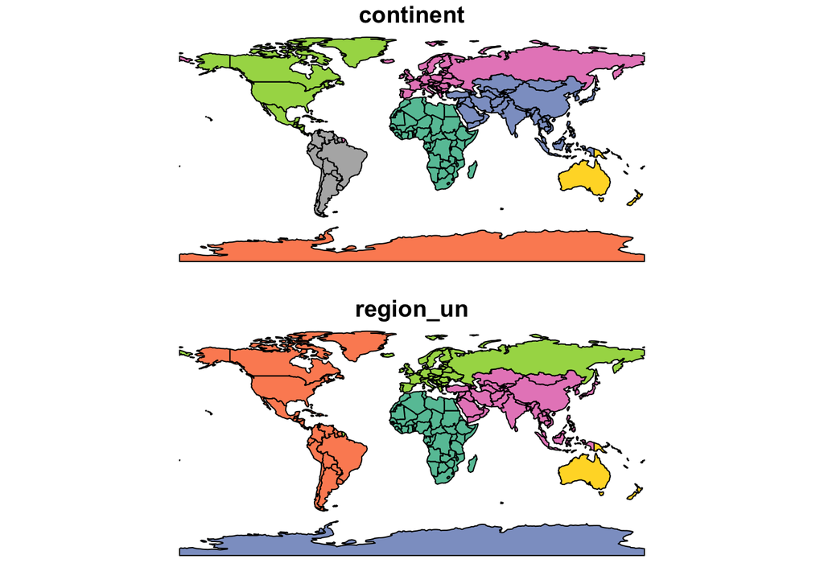

```r
plot(world[3:4])
```

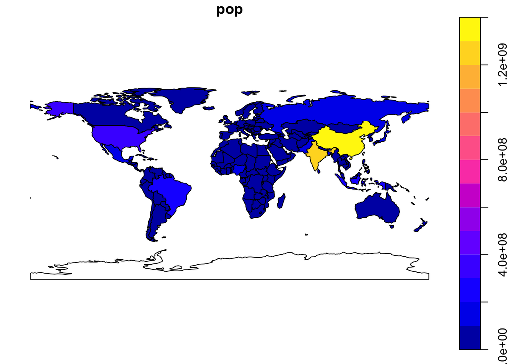

```r
plot(world["pop"])
```

Es posible explorar de manera ágil las estadísticas de cada una de las columnas contenidas en el conjunto de datos.

```r
summary(world["lifeExp"])
```

```
##     lifeExp                 geom
##  Min.   :48.93   MULTIPOLYGON :177
##  1st Qu.:64.30   epsg:4326    :  0
##  Median :72.83   +proj=long...:  0
##  Mean   :70.62
##  3rd Qu.:77.12
##  Max.   :83.59
##  NA's   :9
```

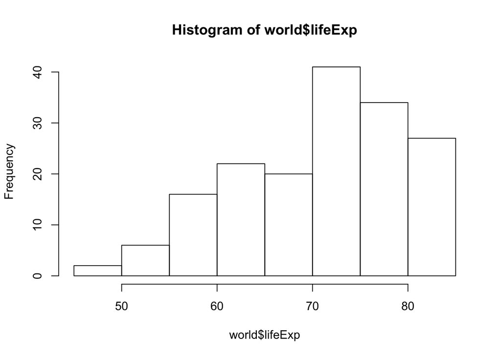

```r
hist(world$lifeExp)
```

La selección de entidades también se puede realizar de manera ágil. Al observar el mapa de población se puedo observar que el continente asiático, se encontraba en el limite superior. Vamos a realizar una selección de los países que pertenecen a este continente.

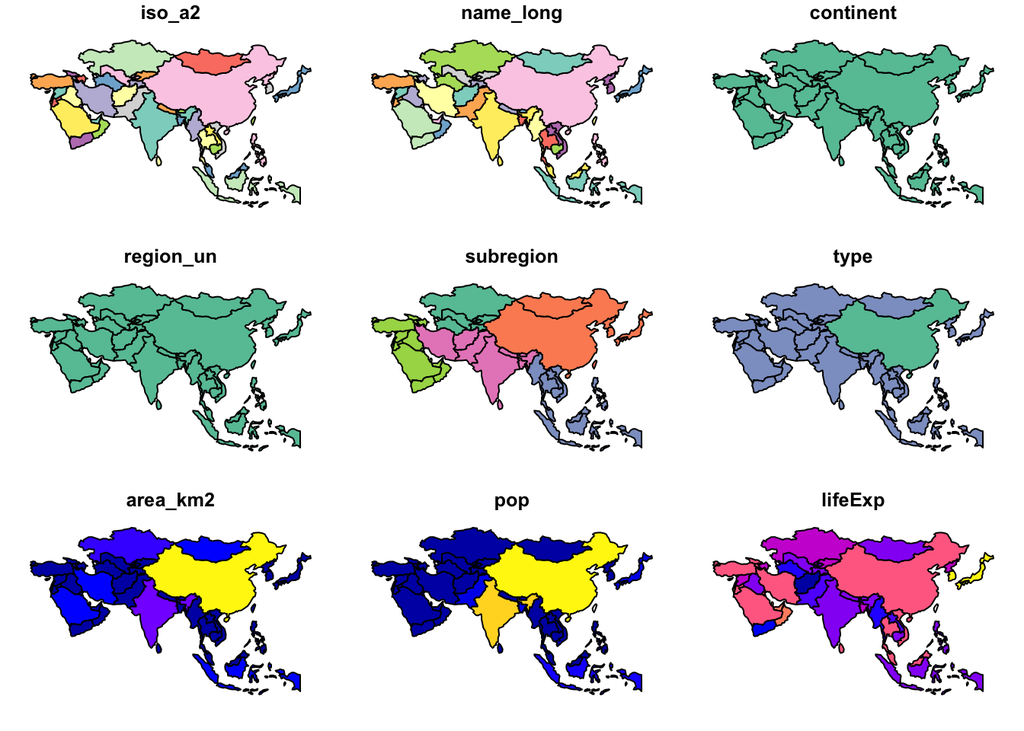

```r
asia <- world[world$continent == "Asia", ]
plot(asia)
```

## Datos de población del censo 2010

Ahora vamos a cargar datos vectoriales en del censo de población y vivienda de México del año 2010.

El primer paso consiste en definir un directorio de trabajo. En este caso el lugar en el cual esta guardada información del archivo practica1, para esto debemos emplear el comando `setwd()`. En el caso de sistemas operativos Linux o mac debe indicarse la siguiente manera `setwd("/Users/alequech/Google Drive/1_Datos_Vectoriales")`, en caso del sistema operativo Windows la ruta se indica de la siguiente manera `C:/Users/Rocket/Google Drive/1_Datos_Vectoriales`.

```r
setwd("/Users/alequech/Google Drive/1.Materias/Analisis_espacial/1_Datos_Vectoriales")
```

Las características sociodemográficas de México por municipio para el año 2010, fueron obtenidas atreves del portal http://www.conabio.gob.mx/informacion/gis/.

```r
dem10gw<-st_read("input/dem10gw.shp")
```

Una manera sencilla de explorar los datos es mediante la función `head`

```r
head(dem10gw)
```

|  | AREA | PERIMETER | CVE_ENT | CVE_MUN | NOM_MUN | MUN_OFICIA | COV_ | COV_ID | EDO_NOM | POTO10 | POMA10 | POFE10 | RE_0_14 | RE_15_39 | RE_40_64 | RE_64 | RE_NE | PORU10 | POUR10 | GRMA10 | geometry |
| --- | --- | --- | --- | --- | --- | --- | --- | --- | --- | --- | --- | --- | --- | --- | --- | --- | --- | --- | --- | --- | --- |
| 1 | 1250860000 | 184387 | 02 | 004 | Tijuana | 02004 | 2 | 1 | BAJA CALIFORNIA | 1559683 | 783653 | 776030 | 455181 | 699908 | 334001 | 59287 | 11306 | 40229 | 1519454 | MUY BAJO |  |
| 2 | 2724360000 | 220197 | 02 | 003 | Tecate | 02003 | 3 | 2 | BAJA CALIFORNIA | 101079 | 53323 | 47756 | 29143 | 44399 | 22055 | 4759 | 723 | 21002 | 80077 | MUY BAJO |  |
| 3 | 14707000000 | 648414 | 02 | 002 | Mexicali | 02002 | 4 | 3 | BAJA CALIFORNIA | 936826 | 473203 | 463623 | 257766 | 395377 | 215741 | 49000 | 18942 | 98710 | 838116 | MUY BAJO |  |
| 4 | 506113000 | 138347 | 02 | 005 | Playas de Rosarito | 02005 | 8 | 7 | BAJA CALIFORNIA | 90668 | 46301 | 44367 | 25953 | 37627 | 19593 | 3887 | 3608 | 14563 | 76105 | MUY BAJO |  |
| 5 | 8961360000 | 529502 | 26 | 055 | San Luis Río Colorado | 26055 | 9 | 8 | SONORA | 178380 | 90545 | 87835 | 54753 | 73516 | 39698 | 9942 | 471 | 10764 | 167616 | MUY BAJO |  |
| 6 | 52616000000 | 1798650 | 02 | 001 | Ensenada | 02001 | 10 | 9 | BAJA CALIFORNIA | 466814 | 235130 | 231684 | 133843 | 201877 | 104556 | 23692 | 2846 | 68692 | 398122 | MUY BAJO |  |

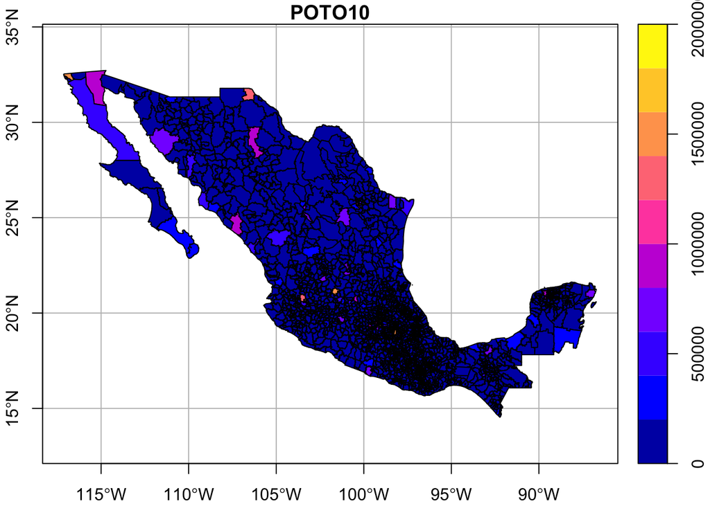

```r
plot(dem10gw["POTO10"],graticule = st_crs(dem10gw), axes = TRUE)
```

```r
estados <- group_by(dem10gw,EDO_NOM) %>% summarize(pop = sum(POTO10, na.rm = TRUE))
```

Realizaremos una selección para los municipios pertenecientes al estado de Michoacán.

```r
michoacan<-dem10gw[dem10gw$CVE_ENT == 16, ]
head(michoacan)
```

```
## Simple feature collection with 6 features and 20 fields
## geometry type:  POLYGON
## dimension:      XY
## bbox:           xmin: -102.5415 ymin: 20.15085 xmax: -101.4402 ymax: 20.39456
## epsg (SRID):    4326
## proj4string:    +proj=longlat +datum=WGS84 +no_defs
##          AREA PERIMETER CVE_ENT CVE_MUN             NOM_MUN MUN_OFICIA
## 842 282537000  119413.0      16     069           La Piedad      16069
## 855 226332000   89155.7      16     086            Tanhuato      16086
## 856 173044000   75804.6      16     106           Yurécuaro      16106
## 861  76318400   77748.4      16     060             Numarán      16060
## 862 146467000   69721.5      16     105       Vista Hermosa      16105
## 867 218001000  110181.0      16     113 José Sixto Verduzco      16113
##     COV_ COV_ID             EDO_NOM POTO10 POMA10 POFE10 RE_0_14 RE_15_39
## 842 1076   1075 MICHOACAN DE OCAMPO  99576  47492  52084   28427    40396
```

[output cut: 19 more lines]

```r
tail(michoacan)
```

```
## Simple feature collection with 6 features and 20 fields
## geometry type:  POLYGON
## dimension:      XY
## bbox:           xmin: -103.7119 ymin: 17.91491 xmax: -100.5882 ymax: 18.87539
## epsg (SRID):    4326
## proj4string:    +proj=longlat +datum=WGS84 +no_defs
##            AREA PERIMETER CVE_ENT CVE_MUN         NOM_MUN MUN_OFICIA COV_
## 1535 2049580000    271822      16     038         Huetamo      16038 1865
## 1553 2055300000    329332      16     096     Tumbiscatío      16096 1883
## 1558  466274000    169919      16     077       San Lucas      16077 1888
## 1610 2257640000    389209      16     008          Aquila      16008 1940
## 1613 3424670000    483250      16     010         Arteaga      16010 1943
## 1739 1147960000    275703      16     052 Lázaro Cárdenas      16052 2069
##      COV_ID             EDO_NOM POTO10 POMA10 POFE10 RE_0_14 RE_15_39
## 1535   1864 MICHOACAN DE OCAMPO  41937  20531  21406   12030    15698
```

[output cut: 19 more lines]

Una vez seleccionado seleccionado el estado de Michoacán, revisemos los datos del sistema de referencia. Para esto vamos a emplear la instrucción `st_crs`(*crs* son las iniciales de *coordinate reference system* ).

```r
st_crs(michoacan)
```

```
## Coordinate Reference System:
##   EPSG: 4326
##   proj4string: "+proj=longlat +datum=WGS84 +no_defs"
```

Los datos arrojados por la instrucción anterior se encuentran en dos formatos, el primero es el parámetro `EPGS` ( ver http://www.epsg.org/); `proj4string` el cual proporciona mayor información sobre el elipsoide de referencia y el tipo de proyección. Para mayor información acerca del manejo de estos parámetros consulte https://www.nceas.ucsb.edu/~frazier/RSpatialGuides/OverviewCoordinateReferenceSystems.pdf.

En el caso de México el INEGI (Instituto Nacional de Estadística y Geografía) en su pagina http://www.inegi.org.mx/geo/contenidos/geodesia/sis_coor.aspx , podrá encontrar los parámetros de coordenadas y sistemas de referencia oficiales.

Emplearemos estos parámetros para proyectar, la información del estado de Michoacán empleando la intrucción `st_transform()`.

```r
michoacan_lcc<-st_transform(michoacan,6372)
st_crs(michoacan_lcc)
```

```
## Coordinate Reference System:
##   EPSG: 6372
##   proj4string: "+proj=lcc +lat_1=17.5 +lat_2=29.5 +lat_0=12 +lon_0=-102 +x_0=2500000 +y_0=0 +ellps=GRS80 +towgs84=0,0,0,0,0,0,0 +units=m +no_defs"
```

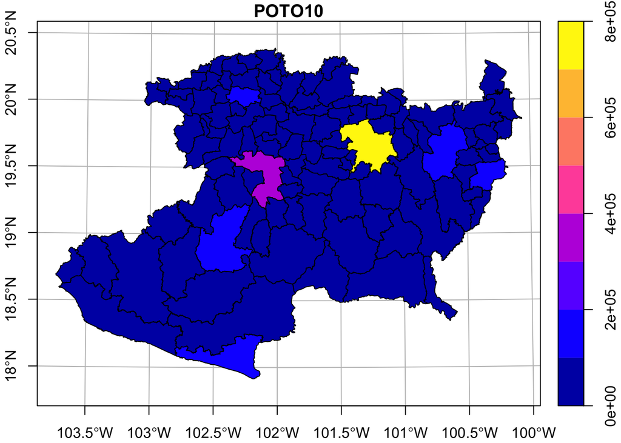

```r
plot(michoacan_lcc["POTO10"],graticule = st_crs(michoacan), axes = TRUE)
```

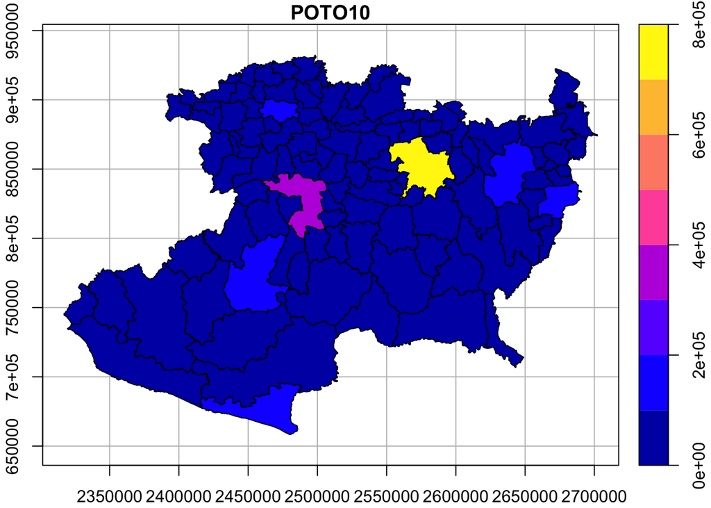

```r
plot(michoacan_lcc["POTO10"],graticule = st_crs(6372), axes = TRUE)
```

Ahora realizaremos un calculo de densidad poblacional para esto calcularemos primero el área.

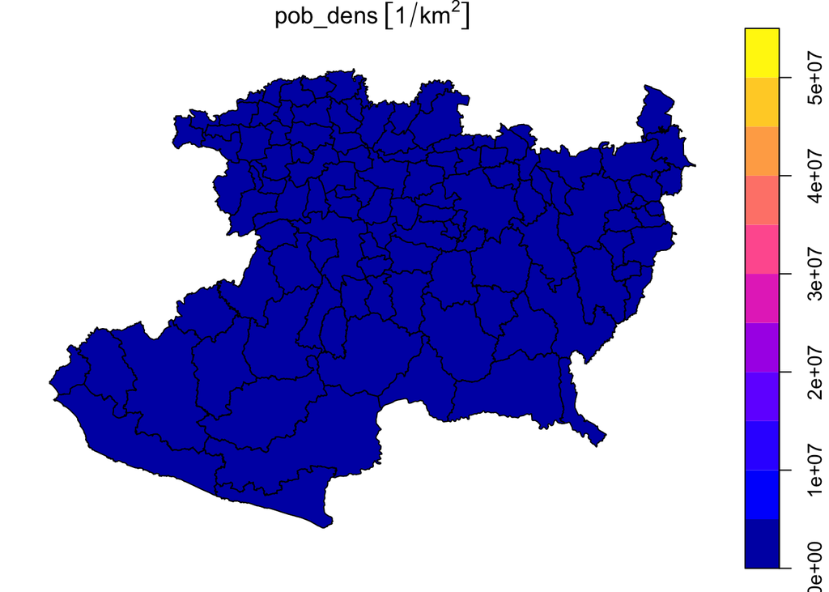

```r
michoacan_lcc$AREA<-st_area(michoacan_lcc)
michoacan_lcc$AREA<-set_units(michoacan_lcc$AREA, km^2)
michoacan_lcc$pob_dens<-michoacan_lcc$POTO10 / michoacan_lcc$AREA
plot(michoacan_lcc["pob_dens"])
```

Agregaremos la población de cada uno de los municipios de acuerdo al grado de marginación.

```r
estado <- aggregate(x = michoacan_lcc[, "POTO10"], by = list(michoacan_lcc$GRMA10), FUN = sum, na.rm = TRUE)
estado$POTO10
```

```
## [1]  164402  956414 1959384  133917 2052301
```

## Ejercicio

1. Proyecte los datos de población de todo el país al sistema de coordenadas Cónico Conforme de Lambert.
2. Calcule la población total en cada uno de los grados de marginación para todo el país.
3. Estime la densidad de población para cada uno de los grados de marginación.